# build_simplicial(): from a network to a shape

honets

2026-08-26

## The analytic question

A graph records which *pairs* of things are related. A simplicial complex records which *groups* are related — and, crucially, it is **closed under subsets**: if `{A, B, C}` is a relation, so are `{A, B}`, `{A, C}` and `{B, C}`.

That closure is not bookkeeping. It is what gives the object a geometry, and therefore a topology: connected pieces, loops, voids. Those are properties no pairwise summary can express.

`build_simplicial()` builds one three ways, selected with `type =`.

```r
library(honets)
set.seed(1)
m <- matrix(runif(100), 10, 10)
m <- (m + t(m)) / 2
diag(m) <- 0
dimnames(m) <- list(LETTERS[1:10], LETTERS[1:10])
```

## `type = "clique"` — from a network

Every clique in the thresholded graph becomes a simplex. A triangle of mutually-connected nodes becomes a filled 2-simplex.

```r
sc <- build_simplicial(m, type = "clique", threshold = 0.5)
sc
```

```
Clique Complex
  10 nodes, 51 simplices, dimension 3
  Density: 13.2%  |  Mean dim: 1.18  |  Euler: -1
  f-vector: (f0=10 f1=24 f2=15 f3=2)
  Betti: b0=1 b1=2
  Nodes: A, B, C, D, E, F, G, H, I, J
```

Ten nodes carry 51 simplices up to dimension 3: 24 edges, 15 triangles and 2 tetrahedra.

```r
as.data.frame(sc, top = 5)
```

```
  id dim size members
1  1   0    1       E
2  2   0    1       G
3  3   0    1       F
4  4   0    1       I
5  5   1    2    E, I
```

```r
as.data.frame(sc, what = "f_vector")
```

```
  dim count
1   0    10
2   1    24
3   2    15
4   3     2
```

The **f-vector** counts faces by dimension and is the complex’s basic fingerprint. `dim = 0` are vertices, `1` edges, `2` triangles, `3` tetrahedra.

```r
as.data.frame(sc, dim = 3, top = 3)
```

```
  id dim size    members
1 25   3    4 A, D, E, I
2 38   3    4 A, C, E, I
```

## Seeing the complex

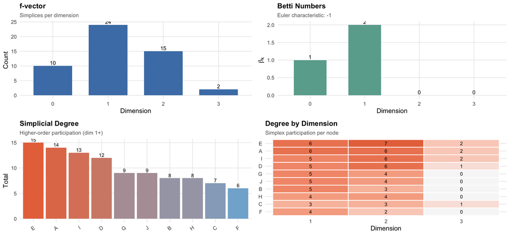

```r
plot(sc)
```

## `threshold` decides the shape

This is the consequential parameter, and its effect is not monotone in any simple way.

```r
do.call(rbind, lapply(c(0.3, 0.4, 0.5, 0.6, 0.7), function(t) {
  s <- build_simplicial(m, type = "clique", threshold = t)
  b <- betti_numbers(s)
  data.frame(threshold = t, simplices = s$n_simplices, dimension = s$dimension,
             euler = euler_characteristic(s),
             b0 = b[["b0"]], b1 = b[["b1"]])
}))
```

```
  threshold simplices dimension euler b0 b1
1       0.3       299         6     1  1  0
2       0.4       174         5     2  1  0
3       0.5        51         3    -1  1  2
4       0.6        31         2    -3  1  4
5       0.7        18         1     2  2  0
```

Watch `b1`, the number of one-dimensional holes. It is **0 at threshold 0.3, rises to 4 at 0.6, then collapses to 0 at 0.7**. At a low threshold the graph is dense enough that every loop is filled in; at a high one it is too sparse to form loops at all. The interesting structure lives in between.

That instability is the whole argument for `persistent_homology()`, which sweeps the threshold instead of committing to one. **Never report a Betti number from a single arbitrary threshold** without showing the sweep.

## `type = "vr"` — from a distance matrix

The Vietoris-Rips complex connects points closer than a scale, then fills in every resulting clique. It is the standard construction for point-cloud data.

```r
set.seed(2)
pts <- matrix(rnorm(40), 20, 2)
d <- as.matrix(dist(pts))
sv <- build_simplicial(d, type = "vr", threshold = 1.5, max_dim = 3L)
sv
```

```
Vietoris-Rips Complex
  20 nodes, 6195 simplices, dimension 3
  Density: 100.0%  |  Mean dim: 2.74  |  Euler: -3875
  f-vector: (f0=20 f1=190 f2=1140 f3=4845)
  Betti: b0=1 b3=3876
```

### `max_dim` is not optional here

A VR complex grows combinatorially. On this 20-point cloud:

```r
do.call(rbind, lapply(c(2L, 3L, 4L), function(md) {
  t0 <- proc.time()[["elapsed"]]
  s <- build_simplicial(d, type = "vr", threshold = 1.5, max_dim = md)
  data.frame(max_dim = md, simplices = s$n_simplices,
             seconds = round(proc.time()[["elapsed"]] - t0, 2))
}))
```

```
  max_dim simplices seconds
1       2      1350    0.05
2       3      6195    0.16
3       4     21699    0.83
```

## `type = "pathway"` — from a memory network

The third route takes a fitted model from the memory family and turns its extracted paths into simplices. See `pathways()` for what each model contributes.

```r
seqs <- split(human_long$code, human_long$session_id)
hon <- build_hon(seqs, max_order = 2, min_freq = 50)
build_simplicial(hon, type = "pathway")
```

```
Pathway Complex
  9 nodes, 29 simplices, dimension 2
  Density: 22.5%  |  Mean dim: 0.90  |  Euler: 1
  f-vector: (f0=9 f1=14 f2=6)
  Betti: b0=2 b1=1
  Nodes: Command, Correct, Frustrate, Inquire, Interrupt, Refine, Request, Specify, Verify
```

Here `b0 = 2` says the well-evidenced pathways split into two disconnected groups of actions — a statement about the corpus that the transition network cannot make.

## Checking the construction

`verify_simplicial()` re-derives the f-vector independently, as a guard against a mis-specified threshold or a malformed matrix.

```r
verify_simplicial(m, threshold = 0.5)
```

```
  Cliques:  MATCH (51 simplices)
  Betti:    b0=1 b1=2 b2=0 b3=0
  Euler:    -1 (Euler-Poincare: VERIFIED)
```

It also confirms the **Euler-Poincaré identity** — the alternating sum of the f-vector equals the alternating sum of the Betti numbers:

```r
fv <- as.data.frame(sc, what = "f_vector")
sum(fv$count * (-1)^fv$dim)
```

```
[1] -1
```

```r
euler_characteristic(sc)
```

```
[1] -1
```

Both give −1. If they ever disagree, the homology computation is wrong.

## What to do next

- **`betti_numbers()`** — what the holes mean, and how to read them.
- **`persistent_homology()`** — the answer to the threshold problem above.
- **`q_analysis()`** — connectivity at each level of overlap, and per-node higher-order degree.
- **`build_hypergraph()`** — the same cliques without the subset-closure requirement.

## References

- Edelsbrunner, H., & Harer, J. (2010). *Computational Topology: An Introduction*. American Mathematical Society.
- Zomorodian, A., & Carlsson, G. (2005). Computing persistent homology. *Discrete & Computational Geometry*, 33(2), 249-274.